# L03 Model Workflows & Recipes

Data Science 2 with R (STAT 301-2)

Author

Allison Kane

**Github Repo Link**

[Allison Repo Link](https://github.com/stat301-2-2024-winter/L03-model-workflows-akane2460.git)

## Exercises

We will be specifying and fitting several models to predict home prices using the KC housing dataset (`data\kc_house_data.csv`). The dataset contains 21,613 house sale prices (`price`) and other information for homes sold between May 2014 and May 2015 in King County, WA.

Code from L02 will likely be useful for reference and/or for building upon.

### Exercise 1

Transformations to be done: 1. From L02 we know that we will want to perform a $log_{10}$ transformation of our outcome variable. 2. We will want to re-type several variables as factors: `waterfront` (nominal/un-ordered), `view` (ordered), `condition` (ordered), and `grade` (ordered).

Perform an initial split of the dataset into testing and training sets using the `rsample` package. Use the default number of strata.

**Solution**

```r
kc_data <- read.csv(here("data/kc_house_data.csv")) |>
  janitor::clean_names()

kc_transformed <- kc_data |>
  mutate(price_log10 = log10(price)) |>
  select(-price)

# factor tranformations
kc_transformed <- kc_transformed |>
  mutate(
    waterfront = factor(waterfront),
    view = factor(view),
    condition = factor(condition),
    grade = factor(grade)
  )

# initial split
kc_split <- kc_transformed |>
  initial_split(prop = .8, strata = price_log10)

kc_train <- kc_split |> training()
kc_test <- kc_split |>  testing()

write_rds(kc_split, file = here("data/kc_split.rds"))
write_rds(kc_train, file = here("data/kc_train.rds"))
write_rds(kc_test, file = here("data/kc_test.rds"))
```

What is the default number of strata used?

**Solution**

The number of breaks strata uses by default is 4. This can be altered only by explicitly stating the number of breaks to be used.

### Exercise 2

Define 4 model types:

- Ordinary linear regression
- Regularized/penalized linear regression (elastic net `glmnet`) with `mixture = 1`, which is called lasso regression, with `penalty = 0.01`.
- Regularized/penalized linear regression (elastic net `glmnet`) with `mixture = 0` which is called ridge regression, with `penalty = 0.01`.
- Random forest model using `ranger` with `trees = 500` and `min_n = 5`

**Solution**

```r
lm_spec <-linear_reg() |>
  set_engine("lm") |>
  set_mode("regression")

# ridge
ridge_spec <-linear_reg(penalty = 0.01, mixture = 0) |>
  set_engine("glmnet") |>
  set_mode("regression")

# lasso
lasso_spec <-linear_reg(penalty = 0.01, mixture = 0) |>
  set_engine("glmnet") |>
  set_mode("regression")

# rf
rf_spec <- rand_forest(trees = 500, min_n = 5) |>
  set_engine("ranger") |>
  set_mode("regression")
```

The models are defined.

### Exercise 3

Define our recipe and set up our workflow. This will allow us to fit our model to our training data and predict on our testing data.

#### Task 1

Define a recipe that uses `waterfront`, `sqft_living`, `yr_built`, and `bedrooms` to predict the target/outcome variable. Add a `step_dummy()` to handle your factor variables.

**Solution**

```r
kc_recipe <- recipe(
  price_log10 ~ waterfront + sqft_living + yr_built + bedrooms,
  data = kc_train) |>
  step_dummy(waterfront)
```

#### Task 2

Create a workflow that adds the model specifications and the recipe. There should be 4 workflows, one for each model type.

**Solution**

```r
lm_wflow <-
  workflow() |>
  add_model(lm_spec) |>
  add_recipe(kc_recipe)

ridge_wflow <-
  workflow() |>
  add_model(ridge_spec) |>
  add_recipe(kc_recipe)

lasso_wflow <-
  workflow() |>
  add_model(lasso_spec) |>
  add_recipe(kc_recipe)

rf_wflow <-
  workflow() |>
  add_model(rf_spec) |>
  add_recipe(kc_recipe)
```

#### Task 3

Train each workflow by fitting the workflow object to the training data. Compare each of the fitted models (except the random forest model) using `broom::tidy()`. Output is not enough, you should write a few sentences.

**Solution**

```
# A tibble: 5 × 5
  term           estimate  std.error statistic   p.value
  <chr>             <dbl>      <dbl>     <dbl>     <dbl>
1 (Intercept)    7.71     0.0847          91.0 0
2 sqft_living    0.000195 0.00000169     116.  0
3 yr_built      -0.00121  0.0000433      -27.9 1.31e-167
4 bedrooms      -0.0197   0.00157        -12.5 8.32e- 36
5 waterfront_X1  0.242    0.0147          16.5 5.40e- 61
```

```
# A tibble: 5 × 3
  term           estimate penalty
  <chr>             <dbl>   <dbl>
1 (Intercept)    7.27        0.01
2 sqft_living    0.000174    0.01
3 yr_built      -0.000984    0.01
4 bedrooms      -0.00830     0.01
5 waterfront_X1  0.251       0.01
```

```
# A tibble: 5 × 3
  term           estimate penalty
  <chr>             <dbl>   <dbl>
1 (Intercept)    6.70        0.01
2 sqft_living    0.000169    0.01
3 yr_built      -0.000703    0.01
4 bedrooms       0           0.01
5 waterfront_X1  0.158       0.01
```

#### Task 4

Evaluate which of the 4 workflows is best by using `predict()` and calculating the RMSE.

**Solution**

```
  price_log10    .pred    difference
1    5.346157 5.515585 -0.1694276282
2    5.730782 5.791843 -0.0610609572
3    5.360783 5.626709 -0.2659266832
4    5.509203 5.596258 -0.0870555734
5    5.602060 5.526117  0.0759428867
6    5.812913 5.812518  0.0003951883
```

```
  price_log10    .pred  difference
1    5.346157 5.526766 -0.18060881
2    5.730782 5.772713 -0.04193025
3    5.360783 5.626310 -0.26552710
4    5.509203 5.603142 -0.09393915
5    5.602060 5.538194  0.06386550
6    5.812913 5.803015  0.00989817
```

```
  price_log10    .pred   difference
1    5.346157 5.524865 -0.178707815
2    5.730782 5.761908 -0.031125389
3    5.360783 5.622455 -0.261672012
4    5.509203 5.610748 -0.101545721
5    5.602060 5.541409  0.060650875
6    5.812913 5.806249  0.006664636
```

```
  price_log10    .pred  difference
1    5.346157 5.554295 -0.20813743
2    5.730782 5.920603 -0.18982102
3    5.360783 5.574389 -0.21360676
4    5.509203 5.562338 -0.05313559
5    5.602060 5.476016  0.12604411
6    5.812913 5.788273  0.02464068
```

[output not shown]

### Exercise 4

The `tidymodels` workflow makes it easy to fit your data to a new recipe or modify an existing recipe.

You only need to complete this Exercise with **ONE** model type (ols, lasso, ridge, or random forest). This time we will be using `waterfront`, `sqft_living`, `sqft_lot`, `bedrooms`, `lat`, and `date` as our predictors.

#### Task 1

First we will pre-process the data by visualizing relationships to determine if a transformation is necessary.

- Visualize the relationship of the outcome variable with `sqft_lot` and `lat`.
- What could an appropriate transformation be for those variables?

**Solution**

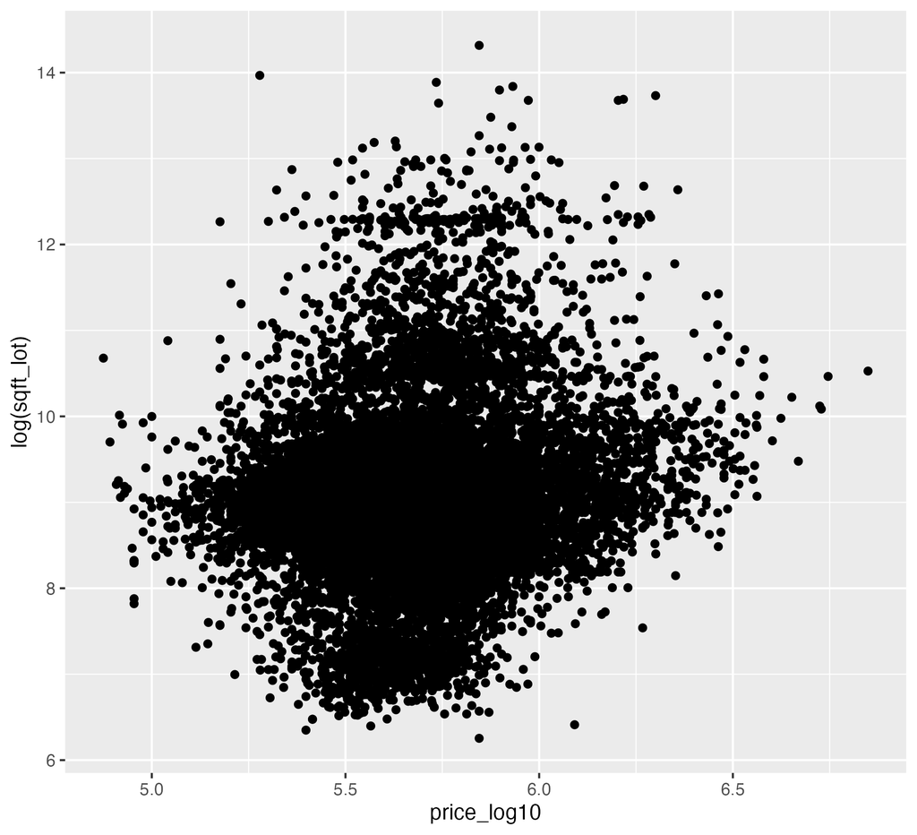

Sqft_lot visualization

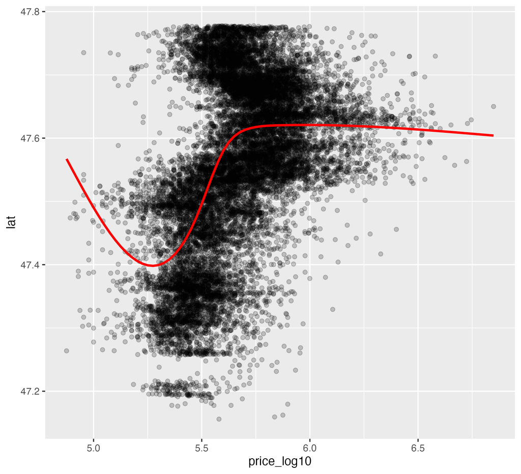

Lat visualization

It seems that sqft_lot does not have an appropriate scale. Transforming it to log_10 scale would be appropriate. Lat seemed to have some alternative scale or formula (definitely not linear), therefore transforming it in the splines package could be helpful.

#### Task 2

Define a recipe that uses `waterfront`, `sqft_living`, `sqft_lot`, `bedrooms`, `lat`, and `date` to predict the target/outcome variable.

- Add a step to transform dummy variables
- Add a step that does an appropriate transformation on `lat`
- Add a step that does an appropriate transformation on `sqft_lot`
- Add a step that extracts the `"month"` feature from `date`; we only want to use the month feature from `date` for prediction and nothing else

Check that the recipe is working as expected by applying it to the training data. Explain how we know the recipe is working as expected.

**Solution**

```r
kc_recipe_adjusted <- recipe(
  price_log10 ~ waterfront + sqft_living + sqft_lot + lat + bedrooms + date,
  data = kc_train) |>
  step_log(sqft_lot) |>
  step_ns(lat, deg_free = 5) |>
  step_date(date, features = "month") |>
  step_dummy(all_nominal_predictors(), one_hot = TRUE) |>
  update_role(date, new_role = "id")
```

```r
# check recipe
kc_recipe_adjusted |>
  prep() |>
  bake(new_data = NULL) |>
  slice(10)
```

```
# A tibble: 1 × 24
  sqft_living sqft_lot bedrooms date                price_log10 lat_ns_1
        <int>    <dbl>    <int> <dttm>                    <dbl>    <dbl>
1        1220     9.00        4 2015-02-13 00:00:00        5.38    0.115
# ℹ 18 more variables: lat_ns_2 <dbl>, lat_ns_3 <dbl>, lat_ns_4 <dbl>,
#   lat_ns_5 <dbl>, waterfront_X0 <dbl>, waterfront_X1 <dbl>,
#   date_month_Jan <dbl>, date_month_Feb <dbl>, date_month_Mar <dbl>,
#   date_month_Apr <dbl>, date_month_May <dbl>, date_month_Jun <dbl>,
#   date_month_Jul <dbl>, date_month_Aug <dbl>, date_month_Sep <dbl>,
#   date_month_Oct <dbl>, date_month_Nov <dbl>, date_month_Dec <dbl>
```

#### Task 3

Define and fit a new workflow using your choice of model specification (1 of the 4 previous defined) and the new recipe from Task 2.

Evaluate the new workflow by using `predict()` and calculating the RMSE. How does the new workflow’s RMSE compare to RMSEs for the previous workflows? Did the new recipe make a difference?

**Solution**

```
  price_log10    .pred  difference
1    5.346157 5.455299 -0.10914185
2    5.730782 5.772602 -0.04181952
3    5.360783 5.581473 -0.22069040
4    5.509203 5.469481  0.03972144
5    5.602060 5.729321 -0.12726064
6    5.812913 5.863597 -0.05068369
```

```
  mean_difference
1     0.002146891
```

Generally, it seems that this adjusted model isn’t better at predicting, based on the typical differences in predicted and actual outcomes of the home sale prices.

#### Task 4

What proportion or percentage of the predicted prices are within 25% of the original price on the testing set? Is this value surprising or not surprising to you? Explain.

**Solution**

```r
rsme_lm_adjusted |>
  mutate(upper_bound = 1.25 * .pred,
         lower_bound = .75 * .pred,
         within = if_else(
           price_log10 >= lower_bound|price_log10 >= lower_bound,
           TRUE,
           FALSE)) |>
  filter(within == FALSE)
```

```
[1] price_log10 .pred       difference  upper_bound lower_bound within
<0 rows> (or 0-length row.names)
```

It seems that 100% of the predicted prices are within 25% of the original price on the testing set. This is somewhat surprising, but given that they typical differences in predicted and actual prices were quite low, it seems that this could make sense.